# Lab 06 Prelab - A review of residuals and fitting

```python
%reset -f
import data_entry2
import numpy as np
import matplotlib.pyplot as plt
```

This prelab focuses on revisting and reinforcing concepts from Lab 05. We start with a review of residual plots.

## Part A - How to read residuals

**Your turn #1a:** Given experimental data and a model for that data, what is a residual?

difference between experimental data and a model

**Your turn #1b:** What are properties of a residual plot that inform us that the model is a good fit to the data?

no trends, points scattered across x-axis and 68% of uncertainty bars are crossing the x-axis

##### **Answer for #1a:**

A residual is defined as the difference between experimental data and a model, i.e., $R_i = y_i - \text{model}(x_i)$ or $R_i = y_i - f(x_i)$.

##### **Answer for #1b:**

A model that is a good fit to the data will have a residual plot with:

- No obvious trend
- A roughly equal scatter of points across the x-axis (x = 0)
- And if the uncertainties are well characterized, we will also see
  - Roughly ~68% of error bars crossing the x-axis
  - Roughly all (~95%) of doubled error bars crossing the x-axis

### Part A1: Diagnosing models with residuals

Now that we have reminded ourselves of how to use residuals to diagnose the goodness of fit of a model to a given set of experimental data, let's use these criteria to diagnose some fits. Below, we have three data sets to which we have tried to fit the model of a straight line with intercept; $y_{\text{model}} = mx + b$. By running the code cells below, we can plot the three data sets with the model, as well as the subsequent residual plot.

For each of the three datasets, point out any features of the residual plot that may indicate that there is a problem of the model fit to the data. Explain what should be changed about the model. Finally, go into the code cell and modify the model according to the diagnosis, until the residual plot indicates that the model is a good fit to the data, as per the criteria discussed in question 1.

```
Sheet name: lab06_prelab_data1.csv
```

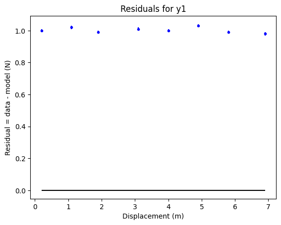

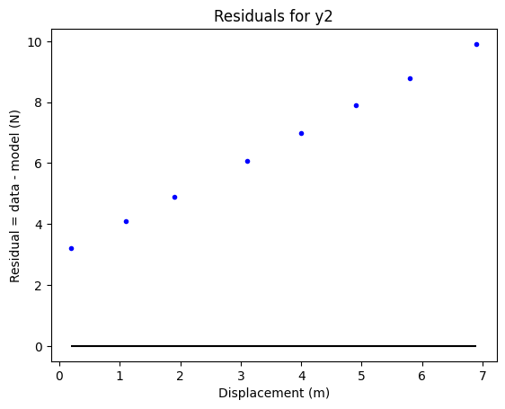

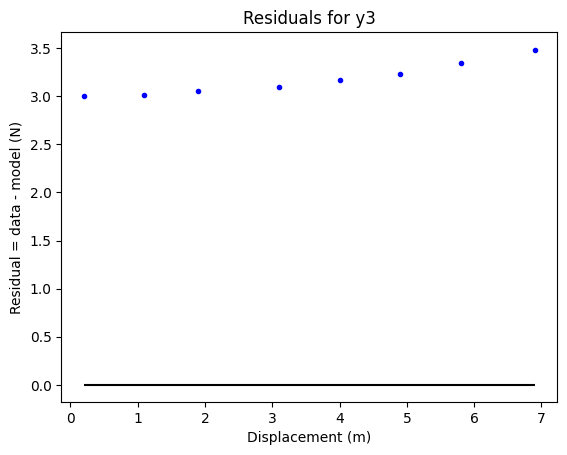

```python
# Run me to load our three data sets
# Make sure to hit the "Generate Vectors" button!
de1 = data_entry2.sheet("lab06_prelab_data1.csv")

slope = 1
xmin = np.min(xVec)
xmax = np.max(xVec)

ymodel = slope * xVec
RVec = y1Vec - ymodel
plt.errorbar(xVec, RVec, uy1Vec, fmt="bo", markersize = 3)
plt.hlines(y=0, xmin=xmin, xmax=xmax, color='k')
plt.title("Residuals for y1")
plt.xlabel("Displacement (m)")
plt.ylabel("Residual = data - model (N)")
plt.show()

RVec = y2Vec - ymodel
plt.errorbar(xVec, RVec, uy2Vec, fmt="bo", markersize = 3)
plt.hlines(y=0, xmin=xmin, xmax=xmax, color='k')
plt.title("Residuals for y2")
plt.xlabel("Displacement (m)")
plt.ylabel("Residual = data - model (N)")
plt.show()

RVec = y3Vec - ymodel
plt.errorbar(xVec, RVec, uy3Vec, fmt="bo", markersize = 3)
plt.hlines(y=0, xmin=xmin, xmax=xmax, color='k')
plt.title("Residuals for y3")
plt.xlabel("Displacement (m)")
plt.ylabel("Residual = data - model (N)")
plt.show()
```

### Your turn #2 (Dataset 1)

View and interact with the plots below to answer the following questions.

**Your turn #2a:** Which feature(s) of the residuals plot below indicates a problem with the fit of the model to the data?

Trend: all points below x-axis

**Your turn #2b:** What should be changed about the model?

Decrease the y-intercept

**Your turn #2c:** Change the model in the code cell (in the area specified) until the residuals indicate the model is a good fit. What are your new slope and/or y-intercept?

Changing the intercept from 1.1 to 1

##### **Answer #2a**

We see a trend in the residuals where all of the residual points lie below the x-axis (x=0 line)

##### **Answer #2b**

The y-intercept of the model is too large, so we should decrease it.

##### **Answer #2c:**

Changing the intercept from 1.1 to 1 in the code improves the model in the desired fashion.

##### **Cell to generate plots for data set 1**

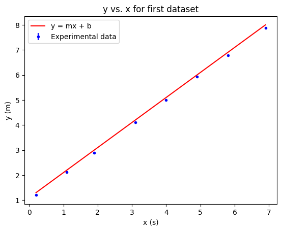

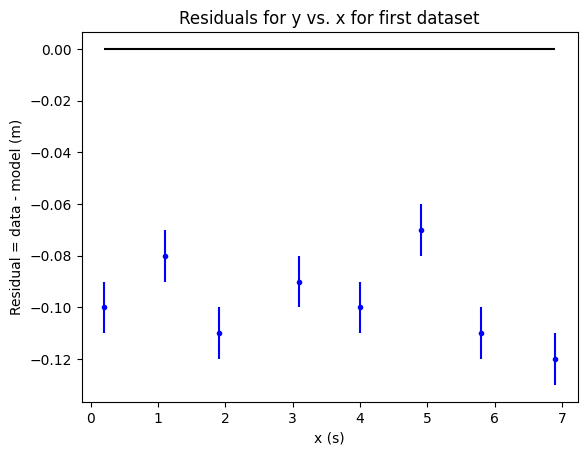

```python
# Run me to make an initial set of plots, to be modified to answer #2c above.

# Data/Model Plot
# Step 1: find the limits of the data:
xmin = np.min(xVec) # use the np.min function to find the smallest x value
xmax = np.max(xVec) # same for max
#print (xmin, xmax)  # uncomment to see what the limits are

# Step 2: generate a bunch of x points between xmin and xmax
xpoints = np.linspace(xmin, xmax, 200) # gives 200 evenly spaced points between xmin and xmax
#print(xpoints) # uncomment to see the x values that were generated.

# Step 3: calculate the model values:
#################################### MODIFY THIS PART ###########################################
slope = 1 # Estimate of the slope.
intercept = 1.1  # Estimate of the intercept
ypoints = xpoints * slope + intercept # this calculates the yvalues at all 200 points.
#################################################################################################

# Step 4: plot the curve. We plot this as a red line "r-" :
plt.plot(xpoints, ypoints, "r-", label = "y = mx + b")

# Plot the data:
plt.errorbar(xVec, y1Vec, uy1Vec, fmt="bo", markersize=3, label="Experimental data")
plt.title("y vs. x for first dataset")
plt.xlabel("x (s)")
plt.ylabel("y (m)")
plt.legend()
plt.show()

# Residuals Plot
# Step 1: Calculate the model at each x-datapoint
ymodel = xVec * slope + intercept

# Step 2: Calcualte the residual vector
RVec = y1Vec - ymodel

# Step 3: Plot the residual vector against the x-data vector
plt.errorbar(xVec, RVec, uy1Vec, fmt="bo", markersize = 3)

# Step 4: Add a R = 0 x-axis (horizontal line) to the plot
plt.hlines(y=0, xmin=xmin, xmax=xmax, color='k') # draw axis at y = 0.

# Add axis labels and title, and show the graph
plt.title("Residuals for y vs. x for first dataset")
plt.xlabel("x (s)")
plt.ylabel("Residual = data - model (m)")
plt.show()
```

### Your turn #3 (Dataset 2)

View and interact with the plots below to answer the following questions.

**Your turn #3a:** Which feature(s) of the residuals plot below indicates a problem with the fit of the model to the data?

increasing linear trend

**Your turn #3b:** What should be changed about the model?

increasing the slope

**Your turn #3c:** Change the model in the code cell (in the area specified) until the residuals indicate the model is a good fit. What are your new slope and/or y-intercept?

increase the slope to 2

##### **Answer #3a**

We see an (upwards) linear trend in the residuals plot.

##### **Answer #3b**

The slope of the model is too small, so we should increase it.

##### **Answer #3c**

Changing the slope from 1.9 to 2 in the code improves the model in the desired fashion.

##### **Cell to generate plots for data set 2**

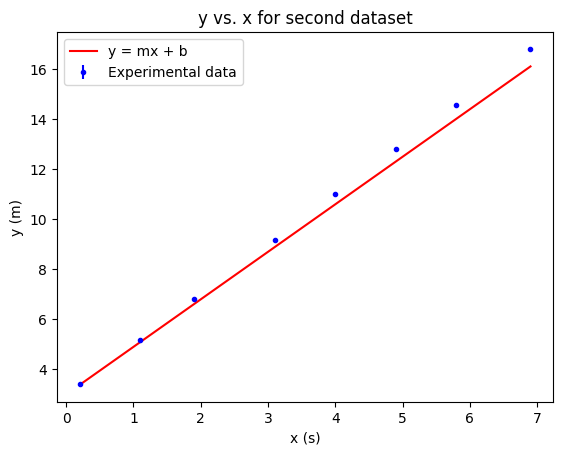

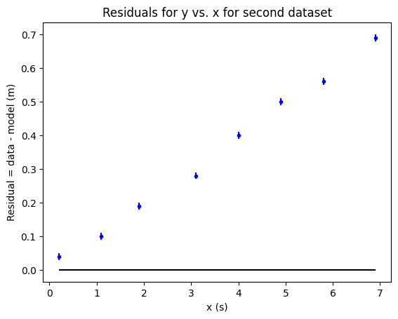

```python
# Run me to make an initial set of plots, to be modified to answer #3c above.

# Data/Model Plot
# Step 1: find the limits of the data:
xmin = np.min(xVec) # use the np.min function to find the smallest x value
xmax = np.max(xVec) # same for max
#print (xmin, xmax)  # uncomment to see what the limits are

# Step 2: generate a bunch of x points between xmin and xmax
xpoints = np.linspace(xmin, xmax, 200) # gives 200 evenly spaced points between xmin and xmax
#print(xpoints) # uncomment to see the x values that were generated.

# Step 3: calculate the model values:
#################################### MODIFY THIS PART ###########################################
slope = 1.9 # Estimate of the slope.
intercept = 3
ypoints = xpoints * slope + intercept # this calculates the yvalues at all 200 points.
#################################################################################################

# Step 4: plot the curve. We plot this as a red line "r-" :
plt.plot(xpoints, ypoints, "r-", label = "y = mx + b")

# Plot the data:
plt.errorbar(xVec, y2Vec, uy2Vec, fmt="bo", markersize=3, label="Experimental data")
plt.title("y vs. x for second dataset")
plt.xlabel("x (s)")
plt.ylabel("y (m)")
plt.legend()
plt.show()

# Residuals Plot
# Step 1: Calculate the model at each x-datapoint
ymodel = xVec * slope + intercept

# Step 2: Calcualte the residual vector
RVec = y2Vec - ymodel

# Step 3: Plot the residual vector against the x-data vector
plt.errorbar(xVec, RVec, uy2Vec, fmt="bo", markersize = 3)

# Step 4: Add a R = 0 x-axis (horizontal line) to the plot
plt.hlines(y=0, xmin=xmin, xmax=xmax, color='k') # draw axis at y = 0.

# Add axis labels and title, and show the graph
plt.title("Residuals for y vs. x for second dataset")
plt.xlabel("x (s)")
plt.ylabel("Residual = data - model (m)")
plt.show()
```

### Your turn #4 (Data set 3)

*Note:* For this data set, the issue with the model is a bit harder to fix compared to the other two examples; for this part it is alright to skip the step of fixing the model in the code, and just comment on what appears to be wrong and how one could feasibly improve the fit of the model to the data (though we welcome the initiative to try to fix the model in the code, as well!)

**Your turn #4a:** Which feature(s) of the residuals plot below indicates a problem with the fit of the model to the data?

plot has an upward trend

**Your turn #4b:** What should be changed about the model?

the model is not a good fit (both the slope and the intercepts are off)

**Your turn #4c (optional):** Change the model in the code cell (in the area specified) until the residuals indicate the model is a good fit. Note that for this question the model is harder to fix in the code compared to the previous two questions; it is therefore a bonus for those who really want to put their python-model-fixing skills to the test. How did you need to adjust your model to make a good fit?

adding $0.01x^2$ to ypoints and change the xVec variable in the y model calculations to $0.01*xVec^2$

##### **Answer #4a**

We notice from the residuals plot that there is a upwards parabolic trend.

##### **Answer #4b**

This parabolic trend tells us that the current linear model is not a good fit for the data; we should add a (positive) quadratic term.

##### **Answer #4c**

To improve it in the desired fashion, we add $0.01x^2$ to the model, which can be done by modifying the code to:

- ypoints = 0.01 * xpoints**2 + xpoints * slope + intercept
- ymodel = 0.01 * xVec**2 + xVec * slope + intercept

##### **Cell to generate plots for data set 3**

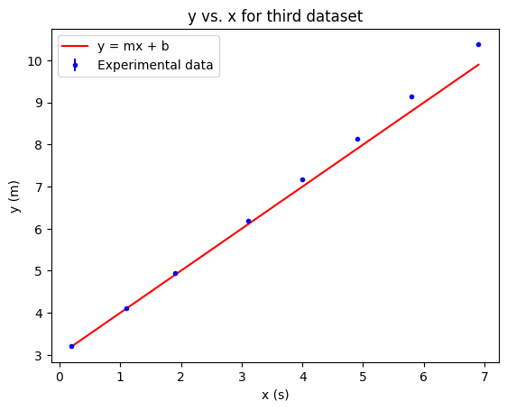

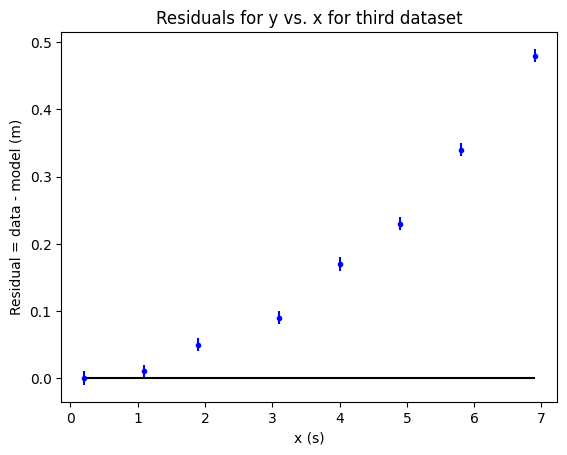

```python
# Run me to make an initial set of plots, to be modified to answer #4c above.

# Data/Model Plot
# Step 1: find the limits of the data:
xmin = np.min(xVec) # use the np.min function to find the smallest x value
xmax = np.max(xVec) # same for max
#print (xmin, xmax)  # uncomment to see what the limits are

# Step 2: generate a bunch of x points between xmin and xmax
xpoints = np.linspace(xmin, xmax, 200) # gives 200 evenly spaced points between xmin and xmax
#print(xpoints) # uncomment to see the x values that were generated.

# Step 3: calculate the model values:
# MODIFY THIS PART ##############################################################################
slope = 1 # Estimate of the slope.
intercept = 3
ypoints = xpoints * slope + intercept # this calculates the yvalues at all 200 points.
#################################################################################################

# Step 4: plot the curve. We plot this as a red line "r-" :
plt.plot(xpoints, ypoints, "r-", label = "y = mx + b")

# Plot the data:
plt.errorbar(xVec, y3Vec, uy3Vec, fmt="bo", markersize=3, label="Experimental data")
plt.title("y vs. x for third dataset")
plt.xlabel("x (s)")
plt.ylabel("y (m)")
plt.legend()
plt.show()

# Residuals Plot
# Step 1: Calculate the model at each x-datapoint
# ALSO MODIFY THIS PART, DEPENDING ON YOUR MODEL MODIFICATION ABOVE###########################
ymodel = xVec * slope + intercept
#################################################################################################

# Step 2: Calcualte the residual vector
RVec = y3Vec - ymodel

# Step 3: Plot the residual vector against the x-data vector
plt.errorbar(xVec, RVec, uy3Vec, fmt="bo", markersize = 3)

# Step 4: Add a R = 0 x-axis (horizontal line) to the plot
plt.hlines(y=0, xmin=xmin, xmax=xmax, color='k') # draw axis at y = 0.

# Add axis labels and title, and show the graph
plt.title("Residuals for y vs. x for third dataset")
plt.xlabel("x (s)")
plt.ylabel("Residual = data - model (m)")
plt.show()
```

## Part B - Using residuals to obtain best fit parameters and their uncertainties

In the Notebook tutorial in lab 5, we learned how to use the residual plot to find the best fit parameters in a linear model and evaluate their uncertainties. We review this procedure here, looking at an experimental setting which gives similar linear data.

### A worked example

An experiment was performed using an electric toy car and an ultrasonic position sensor. The toy car was set into motion (travelling at constant velocity) and the position sensor recorded its position, $d$, every 0.5 seconds. From these data we want to determine the speed and initial position of the toy car. From kinematics, we believe that the toy car's position should follow:

$$d = vt + d_0$$

where $v$ is the speed of the car and $d_0$ is the position at $t=0$. We will therefore model this as a linear model with a non-zero y-intercept.

To begin, we will plot the data and then can make some initial estimates of the slope and y-intercept by looking at the graph or the data table. If we perform a quick rise/run slope calculation using the first and last data points, we get:

$$\text{initial slope estimate} = m = \frac{1.218\text{m}-0.323\text{m}}{3.0\text{s}-0.5\text{s}} = 0.36\text{ m/s}.$$

So we build a scatter plot, with an initial linear model using the estimated parameters above, and then build a residuals plot as well.

It is also worth noticing that uncertainty in the position, $u\_d$, increases as the distance between the car and position sensor increases.

```python
# Run me to load our second data set
# Make sure to hit the "Generate Vectors" button!

de2 = data_entry2.sheet("lab06_prelab_data2.csv")
```

```
Sheet name: lab06_prelab_data2.csv
```

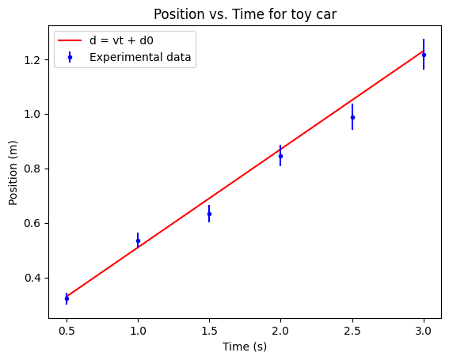

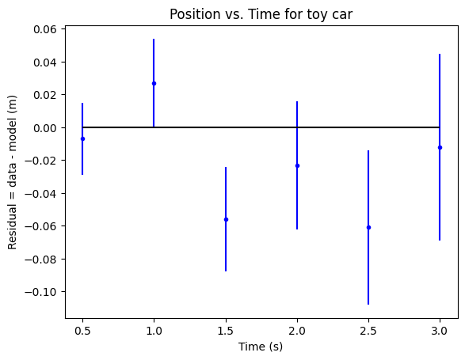

```python
# Run me to make an initial set of plots using m = 0.36 and b = 0.15 for initial model estimates

# Data/Model Plot
# Step 1: find the limits of the data:
xmin = np.min(tVec) # use the np.min function to find the smallest x value
xmax = np.max(tVec) # same for max
#print (xmin, xmax)  # uncomment to see what the limits are

# Step 2: generate a bunch of x points between xmin and xmax
xpoints = np.linspace(xmin, xmax, 200) # gives 200 evenly spaced points between xmin and xmax
#print(xpoints) # uncomment to see the x values that were generated.

# Step 3: calculate the model values:
slope = 0.36  # Estimate of the slope.
intercept = 0.15  # Estimate of the intercept
ypoints = xpoints * slope + intercept # this calculates the yvalues at all 200 points.

# Step 4: plot the curve. We plot this as a red line "r-" :
plt.plot(xpoints, ypoints, "r-", label = "d = vt + d0")

# Plot the data:
plt.errorbar(tVec, dVec, udVec, fmt="bo", markersize=3, label="Experimental data")
plt.title("Position vs. Time for toy car")
plt.xlabel("Time (s)")
plt.ylabel("Position (m)")
plt.legend()
plt.show()

# Residuals Plot
# Step 1: Calculate the model at each x-datapoint
ymodel = tVec * slope + intercept

# Step 2: Calcualte the residual vector
RVec = dVec - ymodel

# Step 3: Plot the residual vector against the x-data vector
plt.errorbar(tVec, RVec, udVec, fmt="bo", markersize = 3)

# Step 4: Add a R = 0 x-axis (horizontal line) to the plot
plt.hlines(y=0, xmin=xmin, xmax=xmax, color='k') # draw axis at y = 0.

# Add axis labels and title, and show the graph
plt.title("Position vs. Time for toy car")
plt.xlabel("Time (s)")
plt.ylabel("Residual = data - model (m)")
plt.show()
```

Looking at the scatter plot above, it looks like our data are roughly linear and that our initial guesses of $m$ and $d_0$ produce a somewhat reasonable model. However, we will make use of the residuals plot and our criteria of good model fits to improve our current fit:

*Criteria: The scatter of the residuals for a good fit will follow a Gaussian distribution with a mean of 0, which means we are looking for a roughly equal number of residuals above the y=0 line as below it. Ideally we should also see no obvious trend/shape in the residuals plot.*

Let’s use these criteria to make some small adjustments to the slope and intercept of our model. First, notice that the residuals plot shows a small trend where they are slowly decreasing from left to right. Decreasing our slope slightly could fix this, since a smaller slope will decrease the model values more at larger $t$ values, reducing the difference between data and model (the residual) more on the right-hand side of the graph than the left-hand side.